# Dendrochronology in R

Jen Baron, j.baron@alumni.ubc.ca, UBC Tree Ring Lab

May 15, 2020

```r
knitr::opts_chunk$set(warning=FALSE, message=FALSE)
```

# 1 Packages

```r
library(dplR) # dendrochronology
library(dplyr)
library(ggplot2)
```

# 2 Load Data

```r
pinery.rwl <- read.rwl("data/pinery.rwl")
```

```
## Attempting to automatically detect format.
## Assuming a Tucson format file.
## There appears to be a header in the rwl file
## There are 12 series
## 1        P1809Ae      1946    2017   0.001
## 2        P1809Be      1892    2017   0.001
## 3        P1809Ce      1888    2017   0.001
## 4        P1810Ae      1853    2018   0.001
## 5        P1810Be      1907    2017   0.001
## 6        P1810Ce      1898    2017   0.001
## 7        P1811Ae      1891    2017   0.001
## 8        P1811Be      1887    2017   0.001
## 9        P1811Ce      1889    2017   0.001
## 10       P1812Ae      1889    2018   0.001
## 11       P1812Be      1906    2017   0.001
## 12       P1812De      1905    2017   0.001
```

```r
master_all.rwl <- read.rwl("data/master_all.rwl")
```

```
## Attempting to automatically detect format.
## Assuming a Tucson format file.
## There does not appear to be a header in the rwl file
## There are 119 series
## 1        058021       1679    1981   0.01
## 2        058022       1721    1981   0.01
## 3        058031       1702    1939   0.01
## 4        058032       1689    1939   0.01
## 5        058051       1720    1956   0.01
## 6        058052       1693    1940   0.01
## 7        058061       1685    1967   0.01
## 8        058062       1687    1968   0.01
## 9        058071       1700    1970   0.01
## 10       058072       1691    1970   0.01
## 11       058081       1706    1970   0.01
```

[output cut: 108 more lines]

```r
master.rwl <- read.rwl("data/master_all.rwl")
```

```
## Attempting to automatically detect format.
## Assuming a Tucson format file.
## There does not appear to be a header in the rwl file
## There are 119 series
## 1        058021       1679    1981   0.01
## 2        058022       1721    1981   0.01
## 3        058031       1702    1939   0.01
## 4        058032       1689    1939   0.01
## 5        058051       1720    1956   0.01
## 6        058052       1693    1940   0.01
## 7        058061       1685    1967   0.01
## 8        058062       1687    1968   0.01
## 9        058071       1700    1970   0.01
## 10       058072       1691    1970   0.01
## 11       058081       1706    1970   0.01
```

[output cut: 108 more lines]

```r
mi015.rwl <- read.rwl("data/mi015.rwl")
```

```
## Attempting to automatically detect format.
## Assuming a Tucson format file.
## There appears to be a header in the rwl file
## There are 21 series
## 1        36-1         1920    2002   0.01
## 2        13-3         1912    2002   0.01
## 3        19-3         1937    2002   0.01
## 4        28-1         1933    2002   0.01
## 5        5-1          1937    2002   0.01
## 6        10-4         1928    2002   0.01
## 7        26-3         1929    2002   0.01
## 8        12-4         1962    2002   0.01
## 9        1-4          1950    2002   0.01
## 10       2-1          1936    2002   0.01
## 11       32-3         1916    2002   0.01
## 12       12-1         1958    2002   0.01
## 13       34-2         1943    2002   0.01
## 14       6-4          1987    2002   0.01
## 15       33-1         1917    2002   0.01
## 16       9-2          1916    2002   0.01
## 17       7-2          1973    2002   0.01
## 18       14-4         1973    2002   0.01
## 19       28-3         1922    2002   0.01
## 20       6-2          1928    2002   0.01
## 21       8-1          1984    2002   0.01
```

```r
cana127.rwl <- read.rwl("data/cana127.rwl")
```

```
## Attempting to automatically detect format.
## Assuming a Tucson format file.
## There appears to be a header in the rwl file
## There are 47 series
## 1        dlw01a       1764    1994   0.01
## 2        dlw02a       1716    1994   0.01
## 3        dlw03a       1762    1994   0.01
## 4        DLW04B       1688    1994   0.01
## 5        dlw05b       1771    1994   0.01
## 6        dlw07a       1889    1994   0.01
## 7        dlw08a       1788    1994   0.01
## 8        DLW09A       1736    1994   0.01
## 9        dlw10a       1798    1994   0.01
## 10       dlw11a       1741    1994   0.01
## 11       dlw12a       1704    1994   0.01
```

[output cut: 36 more lines]

```r
cana148.rwl <- read.rwl("data/cana148.rwl")
```

```
## Attempting to automatically detect format.
## Assuming a Tucson format file.
## There appears to be a header in the rwl file
## There are 50 series
## 1        DLA015       1648    1908   0.01
## 2        DLA025       1658    1974   0.01
## 3        DLA014       1675    1944   0.01
## 4        DLA020       1675    1947   0.01
## 5        DLA024       1843    1945   0.01
## 6        DLA011       1680    1920   0.01
## 7        DLA007       1551    1668   0.01
## 8        DLA013       1665    1874   0.01
## 9        DLA023       1699    1906   0.01
## 10       DLA008       1737    1915   0.01
## 11       DLA018       1665    1873   0.01
```

[output cut: 39 more lines]

```r
pa008.rwl <- read.rwl("data/pa008.rwl")
```

```
## Attempting to automatically detect format.
## Assuming a Tucson format file.
## There does not appear to be a header in the rwl file
## There are 24 series
## 1        058021       1679    1981   0.01
## 2        058022       1721    1981   0.01
## 3        058031       1702    1939   0.01
## 4        058032       1689    1939   0.01
## 5        058051       1720    1956   0.01
## 6        058052       1693    1940   0.01
## 7        058061       1685    1967   0.01
## 8        058062       1687    1968   0.01
## 9        058071       1700    1970   0.01
## 10       058072       1691    1970   0.01
## 11       058081       1706    1970   0.01
## 12       058082       1693    1967   0.01
## 13       058101       1693    1970   0.01
## 14       058102       1698    1970   0.01
## 15       058121       1696    1981   0.01
## 16       058122       1711    1981   0.01
## 17       058141       1712    1981   0.01
## 18       058142       1699    1981   0.01
## 19       058151       1705    1970   0.01
## 20       058152       1692    1981   0.01
## 21       058191       1685    1968   0.01
## 22       058201       1730    1940   0.01
## 23       058202       1684    1981   0.01
## 24       058211       1749    1979   0.01
```

```r
rwl.report(pinery.rwl)
```

```
## Number of dated series: 12
## Number of measurements: 1467
## Avg series length: 122.25
## Range:  166
## Span:  1853 - 2018
## Mean (Std dev) series intercorrelation: 0.4705409 (0.08457867)
## Mean (Std dev) AR1: 0.81975 (0.1065681)
## -------------
## Years with absent rings listed by series
##     None
## -------------
## Years with internal NA values listed by series
##     None
```

## 2.1 Basic Summary Statistics

```r
rwl.stats(pinery.rwl)
```

```
##     series first last year  mean median stdev  skew  gini   ar1
## 1  P1809Ae  1946 2017   72 1.261  1.215 0.415 0.758 0.181 0.642
## 2  P1809Be  1892 2017  126 2.074  1.894 1.119 1.197 0.288 0.731
## 3  P1809Ce  1888 2017  130 1.861  1.315 1.610 2.616 0.368 0.908
## 4  P1810Ae  1853 2018  166 1.564  0.861 2.062 3.789 0.501 0.697
## 5  P1810Be  1907 2017  111 1.437  1.316 1.012 3.582 0.300 0.710
## 6  P1810Ce  1898 2017  120 1.585  1.276 1.143 2.899 0.312 0.829
## 7  P1811Ae  1891 2017  127 1.760  0.804 1.997 1.656 0.535 0.937
## 8  P1811Be  1887 2017  131 2.092  1.037 2.257 1.574 0.529 0.951
## 9  P1811Ce  1889 2017  129 2.109  1.228 2.117 1.597 0.491 0.950
## 10 P1812Ae  1889 2018  130 1.303  1.035 0.922 2.228 0.333 0.864
## 11 P1812Be  1906 2017  112 0.957  0.614 0.892 2.125 0.406 0.822
## 12 P1812De  1905 2017  113 0.825  0.745 0.497 2.902 0.270 0.796
```

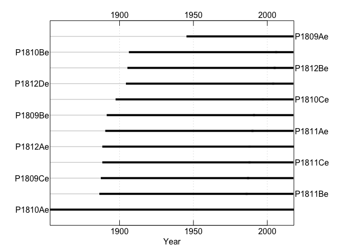

```r
seg.plot(pinery.rwl)
```

## 2.2 Truncate Based on Date / Sample Depth

Truncate to 1898 (sample depth = 8)

```r
pinery.rwl.trunc <- pinery.rwl[46:166,]
#write.rwl(pinery.rwl.trunc, "outputs/pinery_rwl_trunc.rwl", format=c("tucson"))
```

# 3 Crossdating

## 3.1 Interseries Correlation

```r
pinery.corr <- corr.rwl.seg(pinery.rwl.trunc, seg.length = 50, 1918)
```

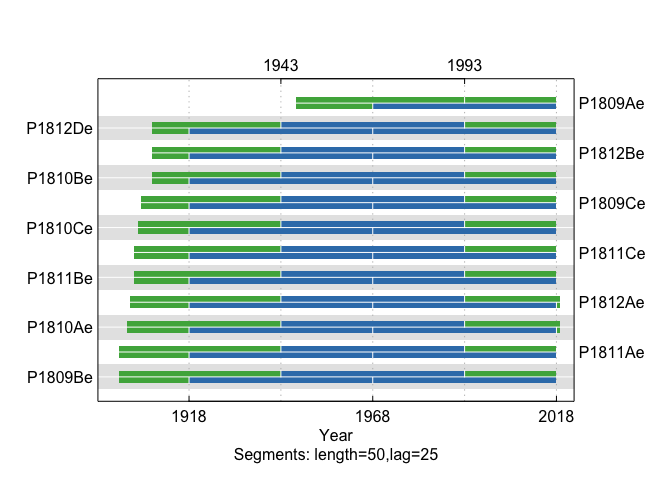

```r
#identify flags
flags <- as.data.frame(pinery.corr$flags)
flags
```

```
## [1] pinery.corr$flags
## <0 rows> (or 0-length row.names)
```

```r
#correlation by series
overall <- pinery.corr$overall
overall %>% round(2)
```

```
##          rho p-val
## P1809Ae 0.60     0
## P1809Be 0.46     0
## P1809Ce 0.52     0
## P1810Ae 0.41     0
## P1810Be 0.58     0
## P1810Ce 0.50     0
## P1811Ae 0.45     0
## P1811Be 0.46     0
## P1811Ce 0.52     0
## P1812Ae 0.53     0
## P1812Be 0.47     0
## P1812De 0.61     0
```

```r
#average series correlation
avg.seg.rho <- as.data.frame(pinery.corr$avg.seg.rho)
avg.seg.rho %>% round(2)
```

```
##           pinery.corr$avg.seg.rho
## 1918.1967                    0.54
## 1943.1992                    0.53
## 1968.2017                    0.51
```

```r
#correlation by segment and series
rho <- as.data.frame(pinery.corr$spearman.rho)
rho %>% round(2)
```

```
##         1918.1967 1943.1992 1968.2017
## P1809Ae        NA        NA      0.69
## P1809Be      0.40      0.37      0.55
## P1809Ce      0.67      0.37      0.54
## P1810Ae      0.49      0.45      0.43
## P1810Be      0.65      0.73      0.62
## P1810Ce      0.61      0.58      0.37
## P1811Ae      0.34      0.49      0.56
## P1811Be      0.50      0.60      0.37
## P1811Ce      0.44      0.49      0.42
## P1812Ae      0.55      0.63      0.64
## P1812Be      0.51      0.50      0.42
## P1812De      0.73      0.66      0.56
```

There is (at least) one other way of looking at the average interseries correlation of a data set. The interseries.cor function in dplR gives a measure of average interseries correlation that is different from the rbar measurements from rwi.stats. In this function, correlations are calculated serially between each tree-ring series and a master chronology built from all the other series in the rwl object (leave-one-out principle).

```r
interseries.p <- interseries.cor(pinery.rwl, prewhiten=FALSE) %>% round(2)
interseries.p
```

```
##         res.cor p.val
## P1809Ae    0.60  0.00
## P1809Be   -0.04  0.66
## P1809Ce    0.63  0.00
## P1810Ae    0.47  0.00
## P1810Be    0.53  0.00
## P1810Ce    0.66  0.00
## P1811Ae    0.64  0.00
## P1811Be    0.58  0.00
## P1811Ce    0.61  0.00
## P1812Ae    0.57  0.00
## P1812Be    0.41  0.00
## P1812De    0.67  0.00
```

```r
interseries.p2 <- interseries.cor(pinery.rwl, prewhiten=TRUE) %>% round(2)
interseries.p2
```

```
##         res.cor p.val
## P1809Ae    0.59     0
## P1809Be    0.39     0
## P1809Ce    0.50     0
## P1810Ae    0.35     0
## P1810Be    0.57     0
## P1810Ce    0.48     0
## P1811Ae    0.45     0
## P1811Be    0.50     0
## P1811Ce    0.39     0
## P1812Ae    0.37     0
## P1812Be    0.47     0
## P1812De    0.60     0
```

```r
interseries.p %>% summarize(mean.r = mean(res.cor) %>% round(2))
```

```
##   mean.r
## 1   0.53
```

```r
interseries.p2 %>% summarize(mean.r = mean(res.cor) %>% round(2))
```

```
##   mean.r
## 1   0.47
```

# 4 Compare to Master Chronologies

See Master Chronology .Rmd for details

```r
master.corr <- corr.rwl.seg(pinery.rwl.trunc, master=master.rwl,seg.length=30, 1853)
```

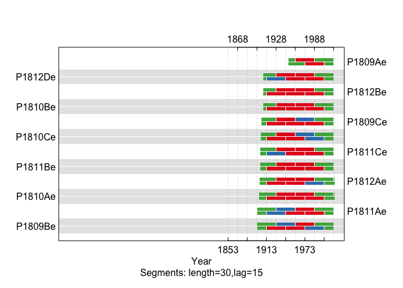

```r
#identify flags
flags.2 <- as.data.frame(master.corr$flags)
flags.2
```

```
##                                             master.corr$flags
## P1809Ae                                  1958.1987, 1973.2002
## P1809Be                       1913.1942, 1943.1972, 1958.1987
## P1809Ce            1913.1942, 1928.1957, 1943.1972, 1973.2002
## P1810Ae 1913.1942, 1928.1957, 1943.1972, 1958.1987, 1973.2002
## P1810Be 1913.1942, 1928.1957, 1943.1972, 1958.1987, 1973.2002
## P1810Ce                       1913.1942, 1928.1957, 1943.1972
## P1811Ae                       1943.1972, 1958.1987, 1973.2002
## P1811Be 1913.1942, 1928.1957, 1943.1972, 1958.1987, 1973.2002
## P1811Ce            1928.1957, 1943.1972, 1958.1987, 1973.2002
## P1812Ae            1913.1942, 1928.1957, 1943.1972, 1958.1987
## P1812Be 1913.1942, 1928.1957, 1943.1972, 1958.1987, 1973.2002
## P1812De            1928.1957, 1943.1972, 1958.1987, 1973.2002
```

```r
#correlation by series
overall.2 <- master.corr$overall %>% as.data.frame()
overall.2 %>% round(2)
```

```
##          rho p-val
## P1809Ae 0.18  0.09
## P1809Be 0.26  0.00
## P1809Ce 0.17  0.05
## P1810Ae 0.02  0.41
## P1810Be 0.04  0.35
## P1810Ce 0.24  0.01
## P1811Ae 0.23  0.01
## P1811Be 0.17  0.04
## P1811Ce 0.21  0.02
## P1812Ae 0.21  0.02
## P1812Be 0.10  0.17
## P1812De 0.15  0.07
```

```r
#average series correlation
avg.seg.rho.2 <- as.data.frame(master.corr$avg.seg.rho)
avg.seg.rho.2 %>% round(2)
```

```
##           master.corr$avg.seg.rho
## 1853.1882                     NaN
## 1868.1897                     NaN
## 1883.1912                     NaN
## 1898.1927                     NaN
## 1913.1942                    0.25
## 1928.1957                    0.19
## 1943.1972                    0.08
## 1958.1987                    0.14
## 1973.2002                    0.16
## 1988.2017                     NaN
```

```r
#correlation by segment and series
rho.2 <- as.data.frame(master.corr$spearman.rho)
rho.2 %>% round(2)
```

```
##         1853.1882 1868.1897 1883.1912 1898.1927 1913.1942 1928.1957 1943.1972
## P1809Ae        NA        NA        NA        NA        NA        NA        NA
## P1809Be        NA        NA        NA        NA      0.25      0.48      0.17
## P1809Ce        NA        NA        NA        NA      0.30      0.26      0.28
## P1810Ae        NA        NA        NA        NA      0.30      0.00     -0.11
## P1810Be        NA        NA        NA        NA      0.09      0.18      0.04
## P1810Ce        NA        NA        NA        NA      0.11      0.14      0.22
## P1811Ae        NA        NA        NA        NA      0.35      0.41      0.14
## P1811Be        NA        NA        NA        NA      0.23      0.02      0.04
## P1811Ce        NA        NA        NA        NA      0.39      0.11     -0.06
## P1812Ae        NA        NA        NA        NA      0.24      0.13      0.05
## P1812Be        NA        NA        NA        NA      0.16      0.17      0.03
## P1812De        NA        NA        NA        NA      0.39      0.16      0.06
##         1958.1987 1973.2002 1988.2017
## P1809Ae      0.16      0.29        NA
## P1809Be      0.02      0.31        NA
## P1809Ce      0.50      0.16        NA
## P1810Ae     -0.07     -0.14        NA
## P1810Be     -0.11      0.11        NA
## P1810Ce      0.46      0.34        NA
## P1811Ae      0.26      0.06        NA
## P1811Be      0.16      0.13        NA
## P1811Ce      0.17      0.27        NA
## P1812Ae      0.04      0.32        NA
## P1812Be      0.08      0.04        NA
## P1812De      0.02      0.03        NA
```

```r
summarize(overall.2, mean = mean(rho)) %>% round(2)
```

```
##   mean
## 1 0.17
```

## 4.2 Compare to Full Regional Chronology

```r
master.corr.all <- corr.rwl.seg(pinery.rwl.trunc, master=master_all.rwl, seg.length=50, 1853)
```

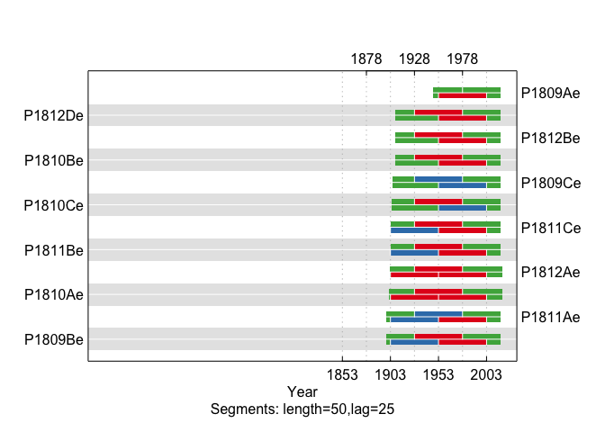

```r
#identify flags
flags.3 <- as.data.frame(master.corr.all$flags)
flags.3
```

```
##                   master.corr.all$flags
## P1809Ae                       1953.2002
## P1809Be            1928.1977, 1953.2002
## P1810Ae 1903.1952, 1928.1977, 1953.2002
## P1810Be            1928.1977, 1953.2002
## P1810Ce                       1928.1977
## P1811Ae                       1953.2002
## P1811Be            1928.1977, 1953.2002
## P1811Ce            1928.1977, 1953.2002
## P1812Ae 1903.1952, 1928.1977, 1953.2002
## P1812Be            1928.1977, 1953.2002
## P1812De            1928.1977, 1953.2002
```

```r
#correlation by series
overall.3 <- master.corr.all$overall %>% as.data.frame()
overall.3 %>% round(2)
```

```
##          rho p-val
## P1809Ae 0.18  0.09
## P1809Be 0.26  0.00
## P1809Ce 0.17  0.05
## P1810Ae 0.02  0.41
## P1810Be 0.04  0.35
## P1810Ce 0.24  0.01
## P1811Ae 0.23  0.01
## P1811Be 0.17  0.04
## P1811Ce 0.21  0.02
## P1812Ae 0.21  0.02
## P1812Be 0.10  0.17
## P1812De 0.15  0.07
```

```r
#average series correlation
avg.seg.rho.3 <- as.data.frame(master.corr.all$avg.seg.rho)
avg.seg.rho.3 %>% round(2)
```

```
##           master.corr.all$avg.seg.rho
## 1853.1902                         NaN
## 1878.1927                         NaN
## 1903.1952                        0.26
## 1928.1977                        0.13
## 1953.2002                        0.09
```

```r
#correlation by segment and series
rho.3 <- as.data.frame(master.corr.all$spearman.rho)
rho.3 %>% round(2)
```

```
##         1853.1902 1878.1927 1903.1952 1928.1977 1953.2002
## P1809Ae        NA        NA        NA        NA      0.21
## P1809Be        NA        NA      0.33      0.19      0.20
## P1809Ce        NA        NA        NA      0.34      0.24
## P1810Ae        NA        NA      0.19     -0.03     -0.21
## P1810Be        NA        NA        NA      0.06      0.01
## P1810Ce        NA        NA        NA      0.18      0.29
## P1811Ae        NA        NA      0.32      0.30     -0.03
## P1811Be        NA        NA      0.25      0.06     -0.01
## P1811Ce        NA        NA      0.29      0.11      0.14
## P1812Ae        NA        NA      0.19      0.05      0.20
## P1812Be        NA        NA        NA      0.09      0.05
## P1812De        NA        NA        NA      0.10      0.03
```

```r
summarize(overall.3, mean = mean(rho)) %>% round(2)
```

```
##   mean
## 1 0.17
```

## 4.3 Compare to Each Master Chronlogy

### 4.3.1 Wyse - Platte Plains - PIST - ITRDB MI015

```r
rwl.report(mi015.rwl)
```

```
## Number of dated series: 21
## Number of measurements: 1302
## Avg series length: 62
## Range:  91
## Span:  1912 - 2002
## Mean (Std dev) series intercorrelation: 0.4915569 (0.1124546)
## Mean (Std dev) AR1: 0.7149524 (0.1194401)
## -------------
## Years with absent rings listed by series
##     Series 19-3 -- 2002
## 1 absent rings (0.077%)
## -------------
## Years with internal NA values listed by series
##     None
```

```r
master.corr.mi015 <- corr.rwl.seg(pinery.rwl.trunc, master=mi015.rwl, seg.length = 30, bin.floor = 1913)
```

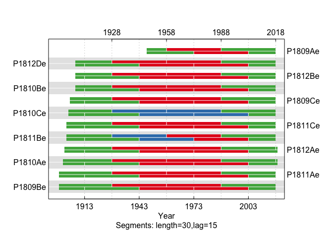

```r
#identify flags
flags.4 <- as.data.frame(master.corr.mi015$flags)
flags.4
```

```
##                            master.corr.mi015$flags
## P1809Ae                       1958.1987, 1973.2002
## P1809Be 1928.1957, 1943.1972, 1958.1987, 1973.2002
## P1809Ce 1928.1957, 1943.1972, 1958.1987, 1973.2002
## P1810Ae 1928.1957, 1943.1972, 1958.1987, 1973.2002
## P1810Be 1928.1957, 1943.1972, 1958.1987, 1973.2002
## P1811Ae 1928.1957, 1943.1972, 1958.1987, 1973.2002
## P1811Be                       1958.1987, 1973.2002
## P1811Ce 1928.1957, 1943.1972, 1958.1987, 1973.2002
## P1812Ae 1928.1957, 1943.1972, 1958.1987, 1973.2002
## P1812Be 1928.1957, 1943.1972, 1958.1987, 1973.2002
## P1812De 1928.1957, 1943.1972, 1958.1987, 1973.2002
```

```r
#correlation by series
overall.4 <- master.corr.mi015$overall %>% as.data.frame()
overall.4 %>% round(2)
```

```
##           rho p-val
## P1809Ae  0.20  0.07
## P1809Be  0.14  0.10
## P1809Ce  0.19  0.04
## P1810Ae -0.04  0.64
## P1810Be  0.21  0.03
## P1810Ce  0.38  0.00
## P1811Ae  0.10  0.17
## P1811Be  0.23  0.02
## P1811Ce  0.07  0.26
## P1812Ae  0.13  0.12
## P1812Be  0.04  0.37
## P1812De  0.12  0.13
```

```r
#average series correlation
avg.seg.rho.4 <- as.data.frame(master.corr.mi015$avg.seg.rho)
avg.seg.rho.4 %>% round(2)
```

```
##           master.corr.mi015$avg.seg.rho
## 1913.1942                           NaN
## 1928.1957                          0.19
## 1943.1972                          0.06
## 1958.1987                          0.12
## 1973.2002                          0.12
## 1988.2017                           NaN
```

```r
#correlation by segment and series
rho.4 <- as.data.frame(master.corr.mi015$spearman.rho)
rho.4 %>% round(2)
```

```
##         1913.1942 1928.1957 1943.1972 1958.1987 1973.2002 1988.2017
## P1809Ae        NA        NA        NA      0.12      0.12        NA
## P1809Be        NA      0.19      0.10      0.02      0.16        NA
## P1809Ce        NA      0.23      0.01      0.23      0.20        NA
## P1810Ae        NA     -0.03      0.06      0.04     -0.15        NA
## P1810Be        NA      0.24      0.11      0.11      0.11        NA
## P1810Ce        NA      0.50      0.41      0.47      0.33        NA
## P1811Ae        NA      0.17      0.04      0.13      0.16        NA
## P1811Be        NA      0.36      0.31      0.21      0.15        NA
## P1811Ce        NA      0.25     -0.15     -0.16      0.16        NA
## P1812Ae        NA      0.04      0.02      0.09      0.14        NA
## P1812Be        NA      0.10     -0.10     -0.01      0.02        NA
## P1812De        NA      0.04     -0.14      0.16      0.08        NA
```

```r
summarize(overall.4, mean = mean(rho)) %>% round(2)
```

```
##   mean
## 1 0.15
```

### 4.3.2 Guyette - Dividing Lake - PIST - ITRDB CANA127

```r
rwl.report(cana127.rwl)
```

```
## Number of dated series: 47
## Number of measurements: 10839
## Avg series length: 230.617
## Range:  333
## Span:  1662 - 1994
## Mean (Std dev) series intercorrelation: 0.5399936 (0.1049041)
## Mean (Std dev) AR1: 0.815617 (0.1225253)
## -------------
## Years with absent rings listed by series
##     None
## -------------
## Years with internal NA values listed by series
##     None
```

```r
master.corr.cana127 <- corr.rwl.seg(pinery.rwl.trunc, master=cana127.rwl, seg.length = 30, bin.floor=1905)
```

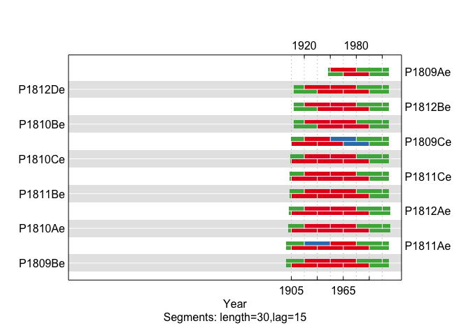

```r
#identify flags
flags.5 <- as.data.frame(master.corr.cana127$flags)
flags.5
```

```
##                                     master.corr.cana127$flags
## P1809Ae                                  1950.1979, 1965.1994
## P1809Be 1905.1934, 1920.1949, 1935.1964, 1950.1979, 1965.1994
## P1809Ce                       1905.1934, 1920.1949, 1935.1964
## P1810Ae 1905.1934, 1920.1949, 1935.1964, 1950.1979, 1965.1994
## P1810Be            1920.1949, 1935.1964, 1950.1979, 1965.1994
## P1810Ce 1905.1934, 1920.1949, 1935.1964, 1950.1979, 1965.1994
## P1811Ae            1905.1934, 1935.1964, 1950.1979, 1965.1994
## P1811Be 1905.1934, 1920.1949, 1935.1964, 1950.1979, 1965.1994
## P1811Ce 1905.1934, 1920.1949, 1935.1964, 1950.1979, 1965.1994
## P1812Ae 1905.1934, 1920.1949, 1935.1964, 1950.1979, 1965.1994
## P1812Be            1920.1949, 1935.1964, 1950.1979, 1965.1994
## P1812De            1920.1949, 1935.1964, 1950.1979, 1965.1994
```

```r
#correlation by series
overall.5 <- master.corr.cana127$overall %>% as.data.frame()
overall.5 %>% round(2)
```

```
##           rho p-val
## P1809Ae  0.02  0.45
## P1809Be  0.21  0.02
## P1809Ce  0.13  0.12
## P1810Ae  0.06  0.27
## P1810Be -0.05  0.68
## P1810Ce  0.10  0.18
## P1811Ae  0.21  0.02
## P1811Be  0.05  0.33
## P1811Ce  0.09  0.19
## P1812Ae  0.14  0.09
## P1812Be  0.09  0.20
## P1812De  0.14  0.10
```

```r
#average series correlation
avg.seg.rho.5 <- as.data.frame(master.corr.cana127$avg.seg.rho)
avg.seg.rho.5 %>% round(2)
```

```
##           master.corr.cana127$avg.seg.rho
## 1905.1934                            0.19
## 1920.1949                            0.07
## 1935.1964                            0.01
## 1950.1979                            0.02
## 1965.1994                            0.08
## 1980.2009                             NaN
```

```r
#correlation by segment and series
rho.5 <- as.data.frame(master.corr.cana127$spearman.rho)
rho.5 %>% round(2)
```

```
##         1905.1934 1920.1949 1935.1964 1950.1979 1965.1994 1980.2009
## P1809Ae        NA        NA        NA      0.01      0.09        NA
## P1809Be      0.19      0.19      0.13     -0.05      0.27        NA
## P1809Ce      0.11      0.07     -0.08      0.45      0.35        NA
## P1810Ae      0.25      0.17     -0.07     -0.25     -0.15        NA
## P1810Be        NA      0.08     -0.04     -0.12     -0.20        NA
## P1810Ce      0.12     -0.11      0.04      0.09      0.26        NA
## P1811Ae      0.17      0.39      0.21     -0.01      0.09        NA
## P1811Be      0.17     -0.05     -0.20     -0.10      0.04        NA
## P1811Ce      0.25      0.09     -0.04      0.01      0.12        NA
## P1812Ae      0.28     -0.10      0.04      0.10      0.10        NA
## P1812Be        NA      0.05      0.02      0.00      0.02        NA
## P1812De        NA     -0.01      0.05      0.07      0.01        NA
```

```r
summarize(overall.5, mean = mean(rho)) %>% round(2)
```

```
##   mean
## 1  0.1
```

### 4.3.3 Guyette - Dividing Lake Aquatic - PIST - ITRDB CANA148

```r
rwl.report(cana148.rwl)
```

```
## Number of dated series: 50
## Number of measurements: 9119
## Avg series length: 182.38
## Range:  1044
## Span:  950 - 1993
## Mean (Std dev) series intercorrelation: 0.4970208 (0.1131863)
## Mean (Std dev) AR1: 0.84128 (0.09196873)
## -------------
## Years with absent rings listed by series
##     None
## -------------
## Years with internal NA values listed by series
##     None
```

```r
master.corr.cana148 <- corr.rwl.seg(pinery.rwl.trunc, master=cana148.rwl, seg.length = 30, bin.floor=1904)
```

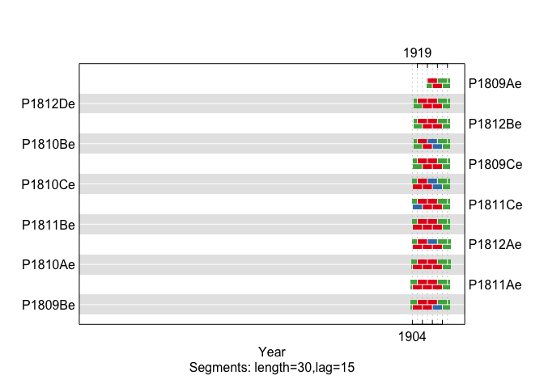

```r
#identify flags
flags.6 <- as.data.frame(master.corr.cana148$flags)
flags.6
```

```
##                                     master.corr.cana148$flags
## P1809Ae                                  1949.1978, 1964.1993
## P1809Be            1904.1933, 1919.1948, 1934.1963, 1949.1978
## P1809Ce            1919.1948, 1934.1963, 1949.1978, 1964.1993
## P1810Ae 1904.1933, 1919.1948, 1934.1963, 1949.1978, 1964.1993
## P1810Be                                  1919.1948, 1934.1963
## P1810Ce                       1904.1933, 1919.1948, 1934.1963
## P1811Ae 1904.1933, 1919.1948, 1934.1963, 1949.1978, 1964.1993
## P1811Be 1904.1933, 1919.1948, 1934.1963, 1949.1978, 1964.1993
## P1811Ce            1919.1948, 1934.1963, 1949.1978, 1964.1993
## P1812Ae            1904.1933, 1919.1948, 1934.1963, 1964.1993
## P1812Be            1919.1948, 1934.1963, 1949.1978, 1964.1993
## P1812De            1919.1948, 1934.1963, 1949.1978, 1964.1993
```

```r
#correlation by series
overall.6 <- master.corr.cana148$overall %>% as.data.frame()
overall.6 %>% round(2)
```

```
##          rho p-val
## P1809Ae 0.14  0.17
## P1809Be 0.23  0.01
## P1809Ce 0.10  0.19
## P1810Ae 0.09  0.19
## P1810Be 0.19  0.04
## P1810Ce 0.25  0.01
## P1811Ae 0.24  0.01
## P1811Be 0.16  0.07
## P1811Ce 0.15  0.08
## P1812Ae 0.20  0.03
## P1812Be 0.12  0.13
## P1812De 0.13  0.12
```

```r
#average series correlation
avg.seg.rho.6 <- as.data.frame(master.corr.cana148$avg.seg.rho) %>% as.data.frame
avg.seg.rho.6 %>% round(2)
```

```
##           master.corr.cana148$avg.seg.rho
## 1904.1933                            0.21
## 1919.1948                            0.13
## 1934.1963                            0.03
## 1949.1978                            0.15
## 1964.1993                            0.25
## 1979.2008                             NaN
```

```r
#correlation by segment and series
rho.6 <- as.data.frame(master.corr.cana148$spearman.rho)
rho.6 %>% round(2)
```

```
##         1904.1933 1919.1948 1934.1963 1949.1978 1964.1993 1979.2008
## P1809Ae        NA        NA        NA      0.06      0.22        NA
## P1809Be      0.07      0.17      0.25      0.04      0.33        NA
## P1809Ce        NA      0.18      0.07      0.13      0.13        NA
## P1810Ae      0.22      0.02     -0.11     -0.11      0.07        NA
## P1810Be        NA      0.18      0.16      0.37      0.34        NA
## P1810Ce      0.02      0.07      0.21      0.38      0.52        NA
## P1811Ae      0.28      0.24      0.07      0.14      0.20        NA
## P1811Be      0.24      0.04     -0.11     -0.01      0.24        NA
## P1811Ce      0.37      0.30     -0.03      0.08      0.12        NA
## P1812Ae      0.25      0.06      0.07      0.39      0.23        NA
## P1812Be        NA      0.10     -0.17      0.11      0.30        NA
## P1812De        NA      0.05     -0.12      0.18      0.27        NA
```

```r
summarize(overall.6, mean = mean(rho)) %>% round(2)
```

```
##   mean
## 1 0.17
```

### 4.3.4 Cook - Longfellow Trail - PIST - ITRDB PA008

```r
rwl.report(pa008.rwl)
```

```
## Number of dated series: 24
## Number of measurements: 6435
## Avg series length: 268.125
## Range:  303
## Span:  1679 - 1981
## Mean (Std dev) series intercorrelation: 0.6192482 (0.0761018)
## Mean (Std dev) AR1: 0.8445 (0.07192569)
## -------------
## Years with absent rings listed by series
##     Series 058061 -- 1934
## 1 absent rings (0.016%)
## -------------
## Years with internal NA values listed by series
##     None
```

```r
master.corr.pa008 <- corr.rwl.seg(pinery.rwl.trunc, master=pa008.rwl, seg.length=40, bin.floor = 1902)
```

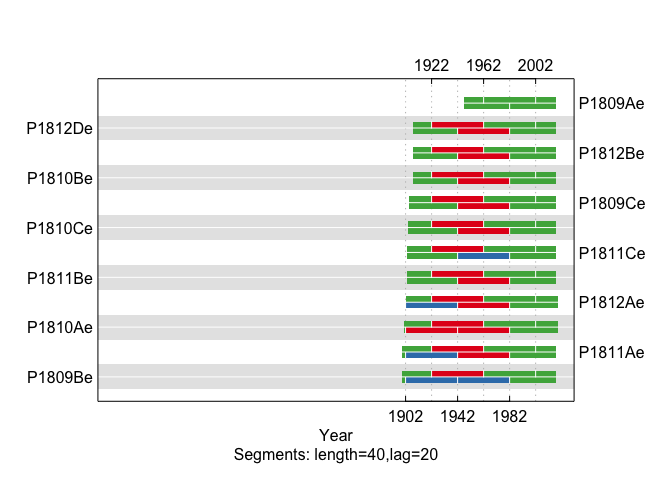

```r
#identify flags
flags.7 <- as.data.frame(master.corr.pa008$flags)
flags.7
```

```
##                 master.corr.pa008$flags
## P1809Be                       1922.1961
## P1809Ce            1922.1961, 1942.1981
## P1810Ae 1902.1941, 1922.1961, 1942.1981
## P1810Be            1922.1961, 1942.1981
## P1810Ce            1922.1961, 1942.1981
## P1811Ae            1922.1961, 1942.1981
## P1811Be            1922.1961, 1942.1981
## P1811Ce                       1922.1961
## P1812Ae            1922.1961, 1942.1981
## P1812Be            1922.1961, 1942.1981
## P1812De            1922.1961, 1942.1981
```

```r
#correlation by series
overall.7 <- master.corr.pa008$overall %>% as.data.frame()
overall.7 %>% round(2)
```

```
##          rho p-val
## P1809Ae 0.11  0.26
## P1809Be 0.35  0.00
## P1809Ce 0.11  0.18
## P1810Ae 0.12  0.15
## P1810Be 0.06  0.31
## P1810Ce 0.13  0.13
## P1811Ae 0.25  0.01
## P1811Be 0.28  0.01
## P1811Ce 0.32  0.00
## P1812Ae 0.22  0.02
## P1812Be 0.14  0.12
## P1812De 0.28  0.01
```

```r
#average series correlation
avg.seg.rho.7 <- as.data.frame(master.corr.pa008$avg.seg.rho)
avg.seg.rho.7 %>% round(2)
```

```
##           master.corr.pa008$avg.seg.rho
## 1902.1941                          0.30
## 1922.1961                          0.08
## 1942.1981                          0.13
## 1962.2001                           NaN
```

```r
#correlation by segment and series
rho.7 <- as.data.frame(master.corr.pa008$spearman.rho)
rho.7 %>% round(2)
```

```
##         1902.1941 1922.1961 1942.1981 1962.2001
## P1809Ae        NA        NA        NA        NA
## P1809Be      0.38      0.25      0.35        NA
## P1809Ce        NA      0.19     -0.02        NA
## P1810Ae      0.18     -0.06      0.04        NA
## P1810Be        NA      0.14      0.12        NA
## P1810Ce        NA     -0.10     -0.05        NA
## P1811Ae      0.33      0.14      0.15        NA
## P1811Be        NA      0.06      0.00        NA
## P1811Ce        NA      0.02      0.37        NA
## P1812Ae      0.31     -0.08      0.15        NA
## P1812Be        NA      0.10      0.16        NA
## P1812De        NA      0.20      0.14        NA
```

```r
summarize(overall.7, mean = mean(rho)) %>% round(2)
```

```
##   mean
## 1  0.2
```

# 5 Compare to Csank

```r
HL.rwl <- read.rwl("data/csank_HL.rwl")
```

```
## Attempting to automatically detect format.
## Assuming a Tucson format file.
## There does not appear to be a header in the rwl file
## There are 36 series
## 1        HL024B       1925    2013   0.001
## 2        HL024A       1897    2013   0.001
## 3        HL023B       1951    2013   0.001
## 4        HL023A       1902    2013   0.001
## 5        HL022B       1938    2013   0.001
## 6        HL022A       1885    2013   0.001
## 7        HL021B       1950    2013   0.001
## 8        HL021A       1880    2013   0.001
## 9        HL020A       1893    2013   0.001
## 10       HL020B       1903    2013   0.001
## 11       HL015A       1892    2013   0.001
```

[output cut: 25 more lines]

```r
KL.rwl <- read.rwl("data/csank_KL.rwl")
```

```
## Attempting to automatically detect format.
## Assuming a Tucson format file.
## There does not appear to be a header in the rwl file
## There are 20 series
## 1        KL001A       1911    2013   0.001
## 2        KL001B       1908    2013   0.001
## 3        KL002A       1917    2013   0.001
## 4        KL002B       1892    2013   0.001
## 5        KL003A       1879    2013   0.001
## 6        KL003B       1882    2013   0.001
## 7        KL004A       1898    2013   0.001
## 8        KL004B       1900    2013   0.001
## 9        KL005A       1891    2013   0.001
## 10       KL005B       1854    2013   0.001
## 11       KL006A       1893    2013   0.001
## 12       KL006B       1904    2013   0.001
## 13       KL007A       1908    2013   0.001
## 14       KL007B       1931    2013   0.001
## 15       KL008A       1902    2013   0.001
## 16       KL008B       1879    2013   0.001
## 17       KL009A       1898    2013   0.001
## 18       KL009B       1875    2013   0.001
## 19       KL010A       1868    2013   0.001
## 20       KL010B       1833    2013   0.001
```

```r
WB.rwl <- read.rwl("data/csank_WB.rwl")
```

```
## Attempting to automatically detect format.
## Assuming a Tucson format file.
## There does not appear to be a header in the rwl file
## There are 32 series
## 1        WB17         1891    2014   0.001
## 2        WB18A        1856    2014   0.001
## 3        WB18B        1890    2014   0.001
## 4        WB19         1844    2014   0.001
## 5        WB20         1882    2014   0.001
## 6        WB12         1783    2014   0.001
## 7        WB10         1816    2014   0.001
## 8        WB05         1829    2014   0.001
## 9        WB01         1860    2014   0.001
## 10       WB06         1896    2014   0.001
## 11       WB08         1833    2011   0.001
```

[output cut: 21 more lines]

### 5.0.1 HL

```r
rwl.report(HL.rwl)
```

```
## Number of dated series: 36
## Number of measurements: 3917
## Avg series length: 108.8056
## Range:  198
## Span:  1816 - 2013
## Mean (Std dev) series intercorrelation: 0.5312548 (0.1357166)
## Mean (Std dev) AR1: 0.7656944 (0.1228716)
## -------------
## Years with absent rings listed by series
##     None
## -------------
## Years with internal NA values listed by series
##     None
```

```r
master.corr.HL <- corr.rwl.seg(pinery.rwl.trunc, master=HL.rwl, seg.length=20, bin.floor=1904)
```

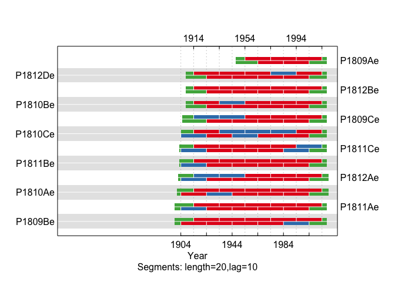

```r
#correlation by series
overall.8 <- master.corr.HL$overall %>% as.data.frame() %>% round(2)

#average series correlation
as.data.frame(master.corr.HL$avg.seg.rho) %>% round(2)
```

```
##           master.corr.HL$avg.seg.rho
## 1904.1923                       0.43
## 1914.1933                       0.24
## 1924.1943                       0.19
## 1934.1953                       0.32
## 1944.1963                       0.08
## 1954.1973                       0.03
## 1964.1983                       0.07
## 1974.1993                       0.27
## 1984.2003                       0.27
## 1994.2013                       0.21
```

```r
summarize(overall.8, mean = mean(rho)) %>% round(2)
```

```
##   mean
## 1 0.23
```

### 5.0.2 KL

```r
rwl.report(KL.rwl)
```

```
## Number of dated series: 20
## Number of measurements: 2457
## Avg series length: 122.85
## Range:  181
## Span:  1833 - 2013
## Mean (Std dev) series intercorrelation: 0.4567807 (0.1866021)
## Mean (Std dev) AR1: 0.69645 (0.08356055)
## -------------
## Years with absent rings listed by series
##     None
## -------------
## Years with internal NA values listed by series
##     None
```

```r
master.corr.KL <- corr.rwl.seg(pinery.rwl.trunc, master=KL.rwl, seg.length=20, bin.floor = 1904)
```

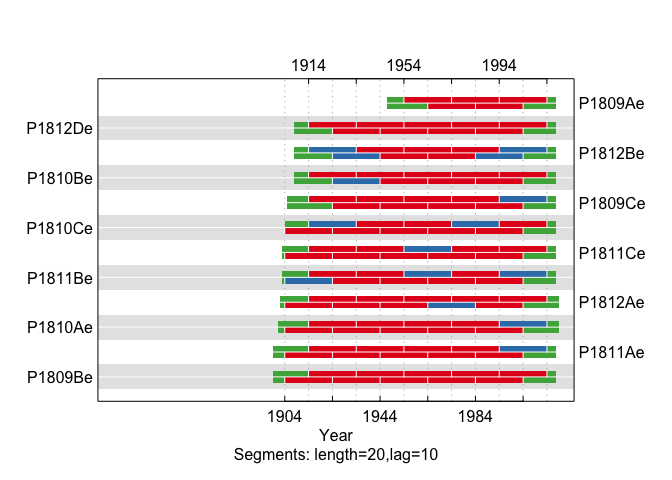

```r
#correlation by series
overall.9 <- master.corr.KL$overall %>% as.data.frame() %>% round(2)

#average series correlation
as.data.frame(master.corr.KL$avg.seg.rho) %>% round(2)
```

```
##           master.corr.KL$avg.seg.rho
## 1904.1923                       0.15
## 1914.1933                       0.27
## 1924.1943                       0.23
## 1934.1953                       0.11
## 1944.1963                       0.01
## 1954.1973                       0.19
## 1964.1983                       0.12
## 1974.1993                       0.16
## 1984.2003                       0.25
## 1994.2013                       0.30
```

```r
summarize(overall.9, mean = mean(rho)) %>% round(2)
```

```
##   mean
## 1 0.18
```

### 5.0.3 WB

```r
rwl.report(WB.rwl)
```

```
## Number of dated series: 32
## Number of measurements: 5875
## Avg series length: 183.5938
## Range:  254
## Span:  1761 - 2014
## Mean (Std dev) series intercorrelation: 0.3726284 (0.199224)
## Mean (Std dev) AR1: 0.8110625 (0.08810146)
## -------------
## Years with absent rings listed by series
##     None
## -------------
## Years with internal NA values listed by series
##     None
```

```r
master.corr.WB <- corr.rwl.seg(pinery.rwl.trunc, master=WB.rwl, seg.length=20, bin.floor = 1904)
```

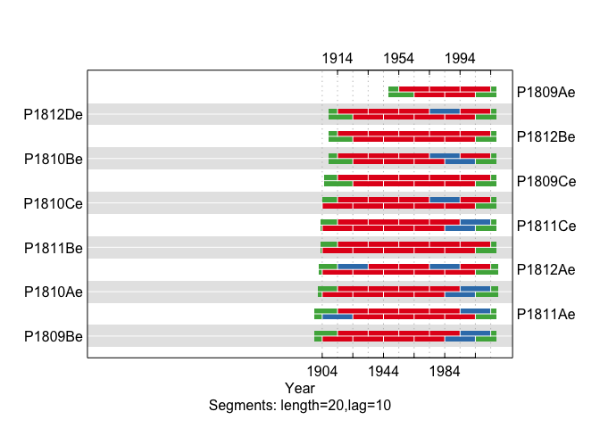

```r
#correlation by series
overall.10 <- master.corr.WB$overall %>% as.data.frame() %>% round(2)

#average series correlation
as.data.frame(master.corr.WB$avg.seg.rho) %>% round(2)
```

```
##           master.corr.WB$avg.seg.rho
## 1904.1923                       0.24
## 1914.1933                       0.13
## 1924.1943                       0.06
## 1934.1953                      -0.01
## 1944.1963                      -0.19
## 1954.1973                      -0.16
## 1964.1983                      -0.10
## 1974.1993                       0.30
## 1984.2003                       0.34
## 1994.2013                       0.20
```

```r
summarize(overall.10, mean = mean(rho)) %>% round(2)
```

```
##   mean
## 1  0.1
```

# 6 Detrending

## 6.1 Compare Methods

```
## Verbose output: P1809Ae
##  ~~~~~~~~~~~~~~~~~~~~~~~~~~~~~~~~~~~~~~~~~~~~~~~~~~~~~~~~~~~~~~~~~~~~~~~~~~~~~~
##  Options
##  make.plot      TRUE
##  method(s)      c("ModNegExp", "Spline")
##  nyrs           NULL
##  f              0.5
##  pos.slope      FALSE
##  constrain.nls  never
##  verbose        TRUE
##  return.info    TRUE
##  wt             default
##  span           cv
##  bass           0
##  difference     FALSE
##
##  ~~~~~~~~~~~~~~~~~~~~~~~~~~~~~~~~~~~~~~~~~~~~~~~~~~~~~~~~~~~~~~~~~~~~~~~~~~~~~~
##  No zeros in input series.
##
##  ~~~~~~~~~~~~~~~~~~~~~~~~~~~~~~~~~~~~~~~~~~~~~~~~~~~~~~~~~~~~~~~~~~~~~~~~~~~~~~
##  Detrend by ModNegExp.
##  Trying to fit nls model...
##  nls failed... fitting linear model... Linear model fit
##  Intercept: 1.110284
##  Slope: 0.004122725
##  lm has a positive slope
##  pos.slope = FALSE
##  Detrend by mean.
##  Mean = 1.260764
##
##  ~~~~~~~~~~~~~~~~~~~~~~~~~~~~~~~~~~~~~~~~~~~~~~~~~~~~~~~~~~~~~~~~~~~~~~~~~~~~~~
##  Detrend by spline.
##  Spline parameters
##  nyrs = 48, f = 0.5
```

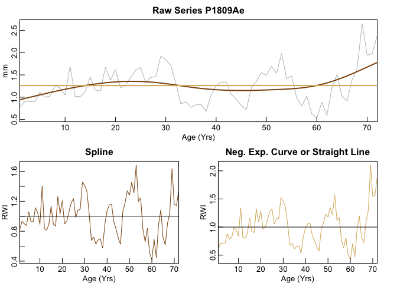

```
## Verbose output: P1809Be
##  ~~~~~~~~~~~~~~~~~~~~~~~~~~~~~~~~~~~~~~~~~~~~~~~~~~~~~~~~~~~~~~~~~~~~~~~~~~~~~~
##  Options
##  make.plot      TRUE
##  method(s)      c("ModNegExp", "Spline")
##  nyrs           NULL
##  f              0.5
##  pos.slope      FALSE
##  constrain.nls  never
##  verbose        TRUE
##  return.info    TRUE
##  wt             default
##  span           cv
##  bass           0
##  difference     FALSE
##
##  ~~~~~~~~~~~~~~~~~~~~~~~~~~~~~~~~~~~~~~~~~~~~~~~~~~~~~~~~~~~~~~~~~~~~~~~~~~~~~~
##  No zeros in input series.
##
##  ~~~~~~~~~~~~~~~~~~~~~~~~~~~~~~~~~~~~~~~~~~~~~~~~~~~~~~~~~~~~~~~~~~~~~~~~~~~~~~
##  Detrend by ModNegExp.
##  Trying to fit nls model...
##  nls failed... fitting linear model... Linear model fit
##  Intercept: 1.502219
##  Slope: 0.01000698
##  lm has a positive slope
##  pos.slope = FALSE
##  Detrend by mean.
##  Mean = 2.107642
##
##  ~~~~~~~~~~~~~~~~~~~~~~~~~~~~~~~~~~~~~~~~~~~~~~~~~~~~~~~~~~~~~~~~~~~~~~~~~~~~~~
##  Detrend by spline.
##  Spline parameters
##  nyrs = 80, f = 0.5
```

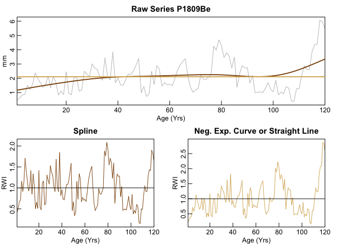

```
## Verbose output: P1809Ce
##  ~~~~~~~~~~~~~~~~~~~~~~~~~~~~~~~~~~~~~~~~~~~~~~~~~~~~~~~~~~~~~~~~~~~~~~~~~~~~~~
##  Options
##  make.plot      TRUE
##  method(s)      c("ModNegExp", "Spline")
##  nyrs           NULL
##  f              0.5
##  pos.slope      FALSE
##  constrain.nls  never
##  verbose        TRUE
##  return.info    TRUE
##  wt             default
##  span           cv
##  bass           0
##  difference     FALSE
##
##  ~~~~~~~~~~~~~~~~~~~~~~~~~~~~~~~~~~~~~~~~~~~~~~~~~~~~~~~~~~~~~~~~~~~~~~~~~~~~~~
##  No zeros in input series.
##
##  ~~~~~~~~~~~~~~~~~~~~~~~~~~~~~~~~~~~~~~~~~~~~~~~~~~~~~~~~~~~~~~~~~~~~~~~~~~~~~~
##  Detrend by ModNegExp.
##  Trying to fit nls model...
##  nls coefs
##  a:  4.3977470
##  b: -0.1766234
##  k:  1.2853264
##
##  ~~~~~~~~~~~~~~~~~~~~~~~~~~~~~~~~~~~~~~~~~~~~~~~~~~~~~~~~~~~~~~~~~~~~~~~~~~~~~~
##  Detrend by spline.
##  Spline parameters
##  nyrs = 80, f = 0.5
```

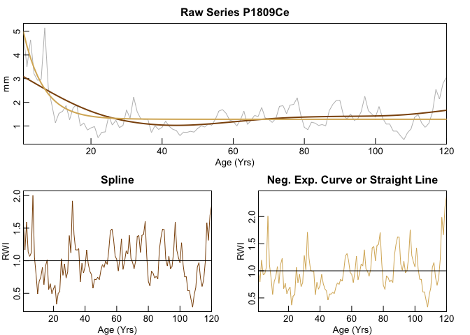

```
## Verbose output: P1810Ae
##  ~~~~~~~~~~~~~~~~~~~~~~~~~~~~~~~~~~~~~~~~~~~~~~~~~~~~~~~~~~~~~~~~~~~~~~~~~~~~~~
##  Options
##  make.plot      TRUE
##  method(s)      c("ModNegExp", "Spline")
##  nyrs           NULL
##  f              0.5
##  pos.slope      FALSE
##  constrain.nls  never
##  verbose        TRUE
##  return.info    TRUE
##  wt             default
##  span           cv
##  bass           0
##  difference     FALSE
##
##  ~~~~~~~~~~~~~~~~~~~~~~~~~~~~~~~~~~~~~~~~~~~~~~~~~~~~~~~~~~~~~~~~~~~~~~~~~~~~~~
##  No zeros in input series.
##
##  ~~~~~~~~~~~~~~~~~~~~~~~~~~~~~~~~~~~~~~~~~~~~~~~~~~~~~~~~~~~~~~~~~~~~~~~~~~~~~~
##  Detrend by ModNegExp.
##  Trying to fit nls model...
##  nls coefs
##  a:  2.1988757
##  b: -0.1325223
##  k:  0.7798402
##
##  ~~~~~~~~~~~~~~~~~~~~~~~~~~~~~~~~~~~~~~~~~~~~~~~~~~~~~~~~~~~~~~~~~~~~~~~~~~~~~~
##  Detrend by spline.
##  Spline parameters
##  nyrs = 81, f = 0.5
```

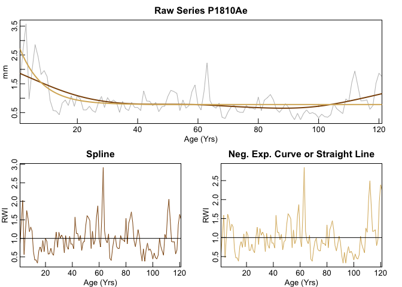

```
## Verbose output: P1810Be
##  ~~~~~~~~~~~~~~~~~~~~~~~~~~~~~~~~~~~~~~~~~~~~~~~~~~~~~~~~~~~~~~~~~~~~~~~~~~~~~~
##  Options
##  make.plot      TRUE
##  method(s)      c("ModNegExp", "Spline")
##  nyrs           NULL
##  f              0.5
##  pos.slope      FALSE
##  constrain.nls  never
##  verbose        TRUE
##  return.info    TRUE
##  wt             default
##  span           cv
##  bass           0
##  difference     FALSE
##
##  ~~~~~~~~~~~~~~~~~~~~~~~~~~~~~~~~~~~~~~~~~~~~~~~~~~~~~~~~~~~~~~~~~~~~~~~~~~~~~~
##  No zeros in input series.
##
##  ~~~~~~~~~~~~~~~~~~~~~~~~~~~~~~~~~~~~~~~~~~~~~~~~~~~~~~~~~~~~~~~~~~~~~~~~~~~~~~
##  Detrend by ModNegExp.
##  Trying to fit nls model...
##  nls coefs
##  a:  9.8709024
##  b: -0.3775278
##  k:  1.2427521
##
##  ~~~~~~~~~~~~~~~~~~~~~~~~~~~~~~~~~~~~~~~~~~~~~~~~~~~~~~~~~~~~~~~~~~~~~~~~~~~~~~
##  Detrend by spline.
##  Spline parameters
##  nyrs = 74, f = 0.5
```

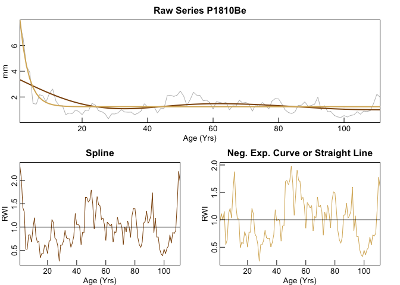

```
## Verbose output: P1810Ce
##  ~~~~~~~~~~~~~~~~~~~~~~~~~~~~~~~~~~~~~~~~~~~~~~~~~~~~~~~~~~~~~~~~~~~~~~~~~~~~~~
##  Options
##  make.plot      TRUE
##  method(s)      c("ModNegExp", "Spline")
##  nyrs           NULL
##  f              0.5
##  pos.slope      FALSE
##  constrain.nls  never
##  verbose        TRUE
##  return.info    TRUE
##  wt             default
##  span           cv
##  bass           0
##  difference     FALSE
##
##  ~~~~~~~~~~~~~~~~~~~~~~~~~~~~~~~~~~~~~~~~~~~~~~~~~~~~~~~~~~~~~~~~~~~~~~~~~~~~~~
##  No zeros in input series.
##
##  ~~~~~~~~~~~~~~~~~~~~~~~~~~~~~~~~~~~~~~~~~~~~~~~~~~~~~~~~~~~~~~~~~~~~~~~~~~~~~~
##  Detrend by ModNegExp.
##  Trying to fit nls model...
##  nls coefs
##  a:  5.3494137
##  b: -0.1212902
##  k:  1.2397702
##
##  ~~~~~~~~~~~~~~~~~~~~~~~~~~~~~~~~~~~~~~~~~~~~~~~~~~~~~~~~~~~~~~~~~~~~~~~~~~~~~~
##  Detrend by spline.
##  Spline parameters
##  nyrs = 80, f = 0.5
```

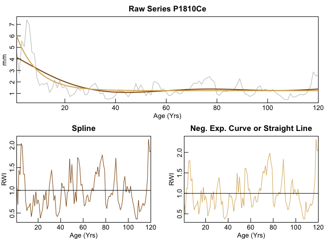

```
## Verbose output: P1811Ae
##  ~~~~~~~~~~~~~~~~~~~~~~~~~~~~~~~~~~~~~~~~~~~~~~~~~~~~~~~~~~~~~~~~~~~~~~~~~~~~~~
##  Options
##  make.plot      TRUE
##  method(s)      c("ModNegExp", "Spline")
##  nyrs           NULL
##  f              0.5
##  pos.slope      FALSE
##  constrain.nls  never
##  verbose        TRUE
##  return.info    TRUE
##  wt             default
##  span           cv
##  bass           0
##  difference     FALSE
##
##  ~~~~~~~~~~~~~~~~~~~~~~~~~~~~~~~~~~~~~~~~~~~~~~~~~~~~~~~~~~~~~~~~~~~~~~~~~~~~~~
##  No zeros in input series.
##
##  ~~~~~~~~~~~~~~~~~~~~~~~~~~~~~~~~~~~~~~~~~~~~~~~~~~~~~~~~~~~~~~~~~~~~~~~~~~~~~~
##  Detrend by ModNegExp.
##  Trying to fit nls model...
##  nls coefs
##  a:  6.95565580
##  b: -0.05960932
##  k:  0.50841242
##
##  ~~~~~~~~~~~~~~~~~~~~~~~~~~~~~~~~~~~~~~~~~~~~~~~~~~~~~~~~~~~~~~~~~~~~~~~~~~~~~~
##  Detrend by spline.
##  Spline parameters
##  nyrs = 80, f = 0.5
```

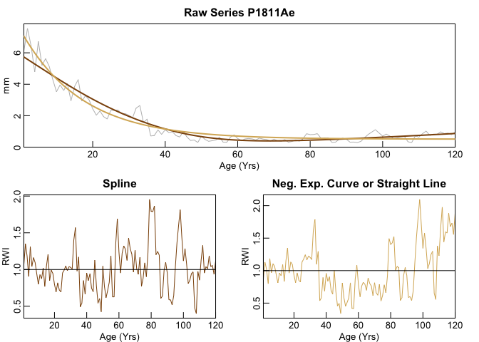

```
## Verbose output: P1811Be
##  ~~~~~~~~~~~~~~~~~~~~~~~~~~~~~~~~~~~~~~~~~~~~~~~~~~~~~~~~~~~~~~~~~~~~~~~~~~~~~~
##  Options
##  make.plot      TRUE
##  method(s)      c("ModNegExp", "Spline")
##  nyrs           NULL
##  f              0.5
##  pos.slope      FALSE
##  constrain.nls  never
##  verbose        TRUE
##  return.info    TRUE
##  wt             default
##  span           cv
##  bass           0
##  difference     FALSE
##
##  ~~~~~~~~~~~~~~~~~~~~~~~~~~~~~~~~~~~~~~~~~~~~~~~~~~~~~~~~~~~~~~~~~~~~~~~~~~~~~~
##  No zeros in input series.
##
##  ~~~~~~~~~~~~~~~~~~~~~~~~~~~~~~~~~~~~~~~~~~~~~~~~~~~~~~~~~~~~~~~~~~~~~~~~~~~~~~
##  Detrend by ModNegExp.
##  Trying to fit nls model...
##  nls coefs
##  a:  6.55348540
##  b: -0.05640673
##  k:  0.65809189
##
##  ~~~~~~~~~~~~~~~~~~~~~~~~~~~~~~~~~~~~~~~~~~~~~~~~~~~~~~~~~~~~~~~~~~~~~~~~~~~~~~
##  Detrend by spline.
##  Spline parameters
##  nyrs = 80, f = 0.5
```

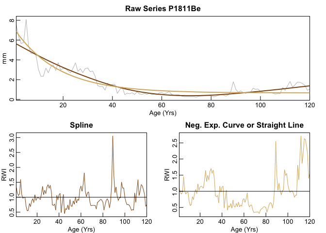

```
## Verbose output: P1811Ce
##  ~~~~~~~~~~~~~~~~~~~~~~~~~~~~~~~~~~~~~~~~~~~~~~~~~~~~~~~~~~~~~~~~~~~~~~~~~~~~~~
##  Options
##  make.plot      TRUE
##  method(s)      c("ModNegExp", "Spline")
##  nyrs           NULL
##  f              0.5
##  pos.slope      FALSE
##  constrain.nls  never
##  verbose        TRUE
##  return.info    TRUE
##  wt             default
##  span           cv
##  bass           0
##  difference     FALSE
##
##  ~~~~~~~~~~~~~~~~~~~~~~~~~~~~~~~~~~~~~~~~~~~~~~~~~~~~~~~~~~~~~~~~~~~~~~~~~~~~~~
##  No zeros in input series.
##
##  ~~~~~~~~~~~~~~~~~~~~~~~~~~~~~~~~~~~~~~~~~~~~~~~~~~~~~~~~~~~~~~~~~~~~~~~~~~~~~~
##  Detrend by ModNegExp.
##  Trying to fit nls model...
##  nls coefs
##  a:  6.85692205
##  b: -0.06779633
##  k:  0.88871951
##
##  ~~~~~~~~~~~~~~~~~~~~~~~~~~~~~~~~~~~~~~~~~~~~~~~~~~~~~~~~~~~~~~~~~~~~~~~~~~~~~~
##  Detrend by spline.
##  Spline parameters
##  nyrs = 80, f = 0.5
```

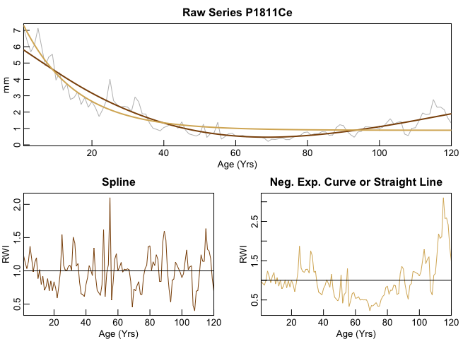

```
## Verbose output: P1812Ae
##  ~~~~~~~~~~~~~~~~~~~~~~~~~~~~~~~~~~~~~~~~~~~~~~~~~~~~~~~~~~~~~~~~~~~~~~~~~~~~~~
##  Options
##  make.plot      TRUE
##  method(s)      c("ModNegExp", "Spline")
##  nyrs           NULL
##  f              0.5
##  pos.slope      FALSE
##  constrain.nls  never
##  verbose        TRUE
##  return.info    TRUE
##  wt             default
##  span           cv
##  bass           0
##  difference     FALSE
##
##  ~~~~~~~~~~~~~~~~~~~~~~~~~~~~~~~~~~~~~~~~~~~~~~~~~~~~~~~~~~~~~~~~~~~~~~~~~~~~~~
##  No zeros in input series.
##
##  ~~~~~~~~~~~~~~~~~~~~~~~~~~~~~~~~~~~~~~~~~~~~~~~~~~~~~~~~~~~~~~~~~~~~~~~~~~~~~~
##  Detrend by ModNegExp.
##  Trying to fit nls model...
##  nls coefs
##  a:  2.9927117
##  b: -0.1494706
##  k:  0.9690993
##
##  ~~~~~~~~~~~~~~~~~~~~~~~~~~~~~~~~~~~~~~~~~~~~~~~~~~~~~~~~~~~~~~~~~~~~~~~~~~~~~~
##  Detrend by spline.
##  Spline parameters
##  nyrs = 81, f = 0.5
```

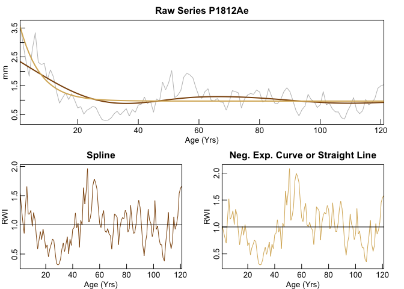

```
## Verbose output: P1812Be
##  ~~~~~~~~~~~~~~~~~~~~~~~~~~~~~~~~~~~~~~~~~~~~~~~~~~~~~~~~~~~~~~~~~~~~~~~~~~~~~~
##  Options
##  make.plot      TRUE
##  method(s)      c("ModNegExp", "Spline")
##  nyrs           NULL
##  f              0.5
##  pos.slope      FALSE
##  constrain.nls  never
##  verbose        TRUE
##  return.info    TRUE
##  wt             default
##  span           cv
##  bass           0
##  difference     FALSE
##
##  ~~~~~~~~~~~~~~~~~~~~~~~~~~~~~~~~~~~~~~~~~~~~~~~~~~~~~~~~~~~~~~~~~~~~~~~~~~~~~~
##  No zeros in input series.
##
##  ~~~~~~~~~~~~~~~~~~~~~~~~~~~~~~~~~~~~~~~~~~~~~~~~~~~~~~~~~~~~~~~~~~~~~~~~~~~~~~
##  Detrend by ModNegExp.
##  Trying to fit nls model...
##  nls coefs
##  a:  3.82955342
##  b: -0.07394128
##  k:  0.51141960
##
##  ~~~~~~~~~~~~~~~~~~~~~~~~~~~~~~~~~~~~~~~~~~~~~~~~~~~~~~~~~~~~~~~~~~~~~~~~~~~~~~
##  Detrend by spline.
##  Spline parameters
##  nyrs = 75, f = 0.5
```

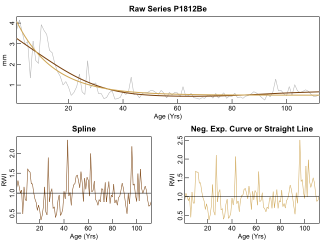

```
## Verbose output: P1812De
##  ~~~~~~~~~~~~~~~~~~~~~~~~~~~~~~~~~~~~~~~~~~~~~~~~~~~~~~~~~~~~~~~~~~~~~~~~~~~~~~
##  Options
##  make.plot      TRUE
##  method(s)      c("ModNegExp", "Spline")
##  nyrs           NULL
##  f              0.5
##  pos.slope      FALSE
##  constrain.nls  never
##  verbose        TRUE
##  return.info    TRUE
##  wt             default
##  span           cv
##  bass           0
##  difference     FALSE
##
##  ~~~~~~~~~~~~~~~~~~~~~~~~~~~~~~~~~~~~~~~~~~~~~~~~~~~~~~~~~~~~~~~~~~~~~~~~~~~~~~
##  No zeros in input series.
##
##  ~~~~~~~~~~~~~~~~~~~~~~~~~~~~~~~~~~~~~~~~~~~~~~~~~~~~~~~~~~~~~~~~~~~~~~~~~~~~~~
##  Detrend by ModNegExp.
##  Trying to fit nls model...
##  nls coefs
##  a:  3.4011237
##  b: -0.2047775
##  k:  0.6929353
##
##  ~~~~~~~~~~~~~~~~~~~~~~~~~~~~~~~~~~~~~~~~~~~~~~~~~~~~~~~~~~~~~~~~~~~~~~~~~~~~~~
##  Detrend by spline.
##  Spline parameters
##  nyrs = 75, f = 0.5
```

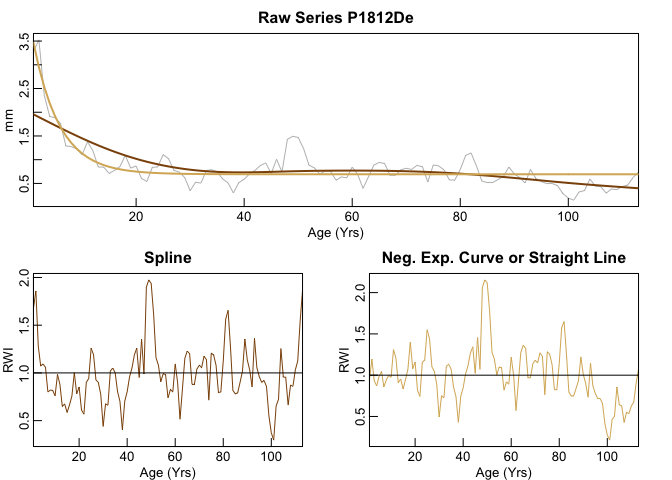

[output not shown]

[output cut: 3558 more lines]

```r
detrend(rwl = pinery.rwl.trunc, method = c("ModNegExp", "Spline"), make.plot = TRUE, verbose=TRUE, return.info = TRUE)
```

## 6.2 Apply Detrending Method

```r
pinery.rwi.info <- detrend(rwl = pinery.rwl.trunc, method = c("ModNegExp"), return.info = TRUE)

pinery.rwi <- pinery.rwi.info$series
```

## 6.3 Descriptive Statistics

### 6.3.1 Read IDs

```r
pinery.ids <- read.ids(pinery.rwl.trunc)
pinery.ids
```

```
##         tree core
## P1809Ae    9    1
## P1809Be    9    2
## P1809Ce    9    3
## P1810Ae   10    1
## P1810Be   10    2
## P1810Ce   10    3
## P1811Ae   11    1
## P1811Be   11    2
## P1811Ce   11    3
## P1812Ae   12    1
## P1812Be   12    2
## P1812De   12    3
```

### 6.3.2 Standard Chronology

```r
rwi.stats(pinery.rwi, pinery.ids, prewhiten=FALSE) #running.window=TRUE, window.length = 50)
```

```
##   n.cores n.trees     n n.tot n.wt n.bt rbar.tot rbar.wt rbar.bt c.eff rbar.eff
## 1      12       4 3.983    66   12   54    0.197   0.414   0.149     3    0.244
##     eps   snr
## 1 0.562 1.284
```

### 6.3.3 Residual Chronology

```r
rwi.stats(pinery.rwi, pinery.ids, prewhiten=TRUE) #running.window=TRUE, window.length = 50)
```

```
##   n.cores n.trees    n n.tot n.wt n.bt rbar.tot rbar.wt rbar.bt c.eff rbar.eff
## 1      12       4 3.95    66   12   54    0.325   0.399   0.309     3    0.516
##     eps   snr
## 1 0.808 4.204
```

### 6.3.4 Interseries Correlations

```r
ic1 <- interseries.cor(pinery.rwi, biweight=TRUE, prewhiten=FALSE) %>% round(3)
ic2 <- interseries.cor(pinery.rwi, biweight=TRUE, prewhiten=TRUE) %>% round(3)

ic1 %>% summarize(mean_cor = mean(res.cor) %>% round(2))
```

```
##   mean_cor
## 1     0.38
```

```r
ic2 %>% summarize(mean_cor = mean(res.cor) %>% round(2))
```

```
##   mean_cor
## 1     0.51
```

Readers interested in the differences between subsample signal strength and the more commonly used (running) expressed population signal should look at Buras (2017) on the common misuse of the expressed population signal as well as Cook and Pederson (2011) for a more general approach to categorizing variability in tree-ring data.

```r
pinery.sss <- sss(pinery.rwl, ids = pinery.ids) %>% round(3)
pinery.sss
```

```
##   [1] 0.545 0.545 0.545 0.545 0.545 0.545 0.545 0.545 0.545 0.545 0.545 0.545
##  [13] 0.545 0.545 0.545 0.545 0.545 0.545 0.545 0.545 0.545 0.545 0.545 0.545
##  [25] 0.545 0.545 0.545 0.545 0.545 0.545 0.545 0.545 0.545 0.545 0.783 0.915
##  [37] 1.000 1.000 1.000 1.000 1.000 1.000 1.000 1.000 1.000 1.000 1.000 1.000
##  [49] 1.000 1.000 1.000 1.000 1.000 1.000 1.000 1.000 1.000 1.000 1.000 1.000
##  [61] 1.000 1.000 1.000 1.000 1.000 1.000 1.000 1.000 1.000 1.000 1.000 1.000
##  [73] 1.000 1.000 1.000 1.000 1.000 1.000 1.000 1.000 1.000 1.000 1.000 1.000
##  [85] 1.000 1.000 1.000 1.000 1.000 1.000 1.000 1.000 1.000 1.000 1.000 1.000
##  [97] 1.000 1.000 1.000 1.000 1.000 1.000 1.000 1.000 1.000 1.000 1.000 1.000
## [109] 1.000 1.000 1.000 1.000 1.000 1.000 1.000 1.000 1.000 1.000 1.000 1.000
## [121] 1.000 1.000 1.000 1.000 1.000 1.000 1.000 1.000 1.000 1.000 1.000 1.000
## [133] 1.000 1.000 1.000 1.000 1.000 1.000 1.000 1.000 1.000 1.000 1.000 1.000
## [145] 1.000 1.000 1.000 1.000 1.000 1.000 1.000 1.000 1.000 1.000 1.000 1.000
## [157] 1.000 1.000 1.000 1.000 1.000 1.000 1.000 1.000 1.000 0.783
```

```r
mean(pinery.sss) %>% round(2)
```

```
## [1] 0.9
```

# 7 Building a Mean Value Chronology

```r
pinery.crn <- chron(pinery.rwi, prewhiten=TRUE, biweight = TRUE)
head(pinery.crn)
```

```
##         xxxstd    xxxres samp.depth
## 1898 0.8671256        NA          8
## 1899 0.8641290 0.9733467          8
## 1900 0.9841930 0.9200743          8
## 1901 0.8159552 0.8260720          8
## 1902 1.1733469 1.2835061          8
## 1903 1.1951044 1.0563245          8
```

```r
#pinery.crn$samp.depth <- NULL
```

Remove standard and residual chronologies

```r
pinery.STD <- pinery.crn %>% select(-xxxres)
pinery.RES <- pinery.crn %>% select(-xxxstd)
```

## 7.1 Plot Chronology

```r
jpeg(file = "figures/chronology.jpeg", width = 18, height = 18, units = "cm", res = 600)

crn.plot(pinery.crn, add.spline = TRUE, nyrs=15)

dev.off()
```

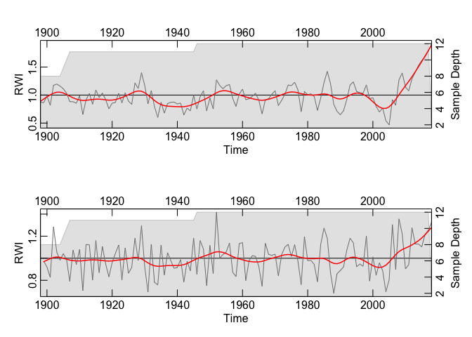

```r
crn.plot(pinery.crn, add.spline = TRUE, nyrs=15)
```

```r
jpeg(file = "figures/chronology_STD.jpeg", width = 18, height = 12, units = "cm", res = 600)

crn.plot(pinery.STD, add.spline = TRUE, nyrs=15)

dev.off()
```

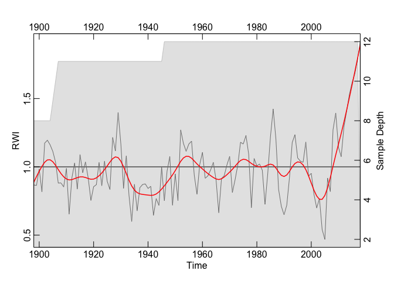

```r
crn.plot(pinery.STD, add.spline = TRUE, nyrs=15)
```

```r
jpeg(file = "figures/chronology_RES.jpeg", width = 18, height = 12, units = "cm", res = 600)

crn.plot(pinery.RES, add.spline = TRUE, nyrs=15)

dev.off()
```

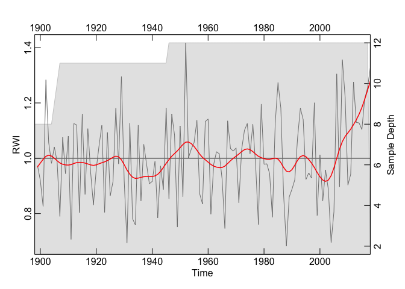

```r
crn.plot(pinery.RES, add.spline = TRUE, nyrs=15)
```

## 7.2 Add Uncertainty Estimates

```r
jpeg(file = "figures/chronology_se.jpeg", width = 18, height = 12, units = "cm", res = 600)


pinery.avg <- apply(pinery.rwi,1,mean,na.rm=TRUE)

yrs <- time(pinery.crn)


se <- function(x){
  x2 <- na.omit(x)
  n <- length(x2)
  sd(x2)/sqrt(n)}


pinery.se <- apply(pinery.rwi,1,se)

pinery.sd <- apply(pinery.rwi,1,sd,na.rm=TRUE)

par(mar = c(2, 2, 2, 2), mgp = c(1.1, 0.1, 0), tcl = 0.25, xaxs='i')

plot(yrs, pinery.avg, type = "n", xlab = "Year", ylab = "RWI", axes=FALSE)
xx <- c(yrs,rev(yrs))
yy <- c(pinery.avg+pinery.se*2,rev(pinery.avg-pinery.se*2))
polygon(xx,yy,col="grey80",border = NA)
lines(yrs, pinery.avg, col = "black")
lines(yrs, ffcsaps(pinery.avg, nyrs = 15), col = "red", lwd = 1) #adds a spline
axis(1); axis(2); axis(3); axis(4)
box()

dev.off()
```

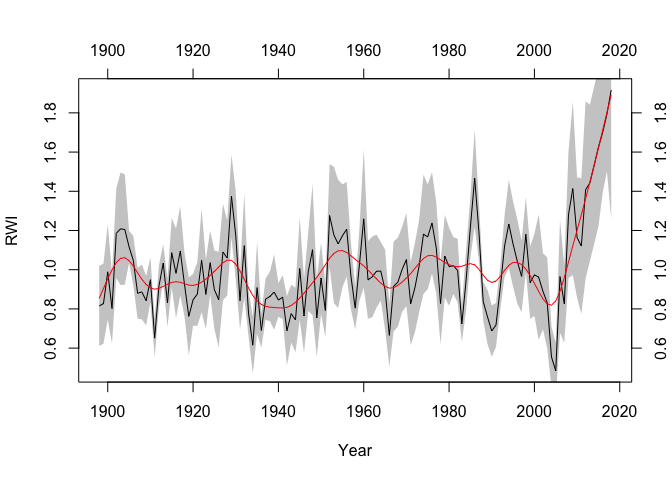

```r
plot(yrs, pinery.avg, type = "n", xlab = "Year", ylab = "RWI", axes=FALSE)
xx <- c(yrs,rev(yrs))
yy <- c(pinery.avg+pinery.se*2,rev(pinery.avg-pinery.se*2))
polygon(xx,yy,col="grey80",border = NA)
lines(yrs, pinery.avg, col = "black")
lines(yrs, ffcsaps(pinery.avg, nyrs = 15), col = "red", lwd = 1) #adds a spline
axis(1); axis(2); axis(3); axis(4)
box()
```

# 8 Save Outputs

```r
write.csv(pinery.se, "outputs/pinery_se.csv")
write.crn(pinery.STD, "outputs/pinery_STD.crn")
```

```
## [1] "outputs/pinery_STD.crn"
```

```r
write.crn(pinery.RES, "outputs/pinery_RES.crn")
```

```
##         xxxres samp.depth
## 1898 9.9900000          0
## 1899 0.9733467          8
## 1900 0.9200743          8
## 1901 0.8260720          8
## 1902 1.2835061          8
## 1903 1.0563245          8
```

```
## [1] "outputs/pinery_RES.crn"
```

# 9 Reproducibility

```r
citation("dplR")
```

```
##
## Bunn AG (2008). "A dendrochronology program library in R (dplR)."
## _Dendrochronologia_, *26*(2), 115-124. ISSN 1125-7865, doi:
## 10.1016/j.dendro.2008.01.002 (URL:
## https://doi.org/10.1016/j.dendro.2008.01.002).
##
## Bunn AG (2010). "Statistical and visual crossdating in R using the dplR
## library." _Dendrochronologia_, *28*(4), 251-258. ISSN 1125-7865, doi:
## 10.1016/j.dendro.2009.12.001 (URL:
## https://doi.org/10.1016/j.dendro.2009.12.001).
##
##   Andy Bunn, Mikko Korpela, Franco Biondi, Filipe Campelo, Pierre
##   Mérian, Fares Qeadan and Christian Zang (2020). dplR:
##   Dendrochronology Program Library in R. R package version 1.7.1.
##   https://CRAN.R-project.org/package=dplR
##
## To see these entries in BibTeX format, use 'print(<citation>,
## bibtex=TRUE)', 'toBibtex(.)', or set
## 'options(citation.bibtex.max=999)'.
```

```r
Sys.time()
```

```
## [1] "2020-08-11 17:10:05 PDT"
```

```r
git2r::repository()
```

```
## Local:    master /Users/JenBaron/Documents/UWO/UWO NSERC/Statistical Analysis/Dendrochronology/Dendrochronology in R/Dendrochronology_in_R
## Remote:   master @ origin (https://github.com/JenBaron/Dendrochronology_in_R.git)
## Head:     [f66d456] 2020-08-12: updated interseries correlation & sss
```